# Overview-PackageTutorial

# Overview of finnsurveytext

This tutorial aims to provide a simple overview of what is included within the `finnsurveytext` package and teach you how to use the main functions included in the package.

The below table shows you all the functions that are included in the package. The functions which are **bolded** are the main functions which are outlined in the sections below.

[output not shown]

# 0. Install and Load Package

First, the `finnsurveytext` package needs to be installed into your R environment and loaded into the environment. You may also want to load in the `survey` package if you want to use a `svydesign` object for the data and/or weights.

```r
library(finnsurveytext)
library(survey)
```

# 1. Data Preparation

The data preparation functions are used to take your raw survey data (in a dataframe or *svydesign* object within your R environment) and convert it into a standardised format ready for analysis.

The functions in the remaining sections require your data to be pre-formatted into this format.

(To learn move about the format we use, see the [Universal Dependencies Project](https://universaldependencies.org/format.html).)

### Option 1: Data is in a dataframe

The package comes with sample data. For this demonstration, we use `dev_coop`. The raw data looks like this:

| fsd_id | q11_1 | q11_2 | q11_3 | paino | gender | region | year_of_birth | education_level |
| --- | --- | --- | --- | --- | --- | --- | --- | --- |
| 1 | elämiseen tarvittavat perusasiat ovat kehittymättöneet (esim. vesi, talo, ruoka). Ja niitä ei ole riittävästi | varmaan koitetaan kehittää em | saastuminen ja luonnonvarojen liikakäyttö, nälänhätä ja ylikansoittuminen | 0.5440 | Female | Etelä-Suomi | 1992 | NA |
| 2 | on kurjuutta ja nälänhätää, asiat eivät ole vielä kehittyneet, lapset eivät pääse kouluun, tytöillä on huonompi asema kuin pojilla. | pyritään auttamaan? | ihmiskauppa, nälänhätä ja sodat/turvattomuus | 0.7171 | Female | Pohjois- ja Itä-Suomi | 1994 | Matriculation examination |
| 3 | jokaisella ei ole turvattua toimeentuloa ja jossa todella huomaa koulutuksen arvon. | autetaan ja näytetään ihmisille tie parempaan tulevaisuuteen heidän oman työnsä tuloksena. | kouluttamattomuus, nälkä ja puhtaan veden puute. | 0.6240 | Female | Helsinki-Uusimaa | 1994 | Matriculation examination |
| 4 | kehityksen taso ei ole yhtä korkea kuin kehittyneissä maissa | yleensä haitataan kehitysmaan kehittymistä | öljy, raha, se fakta että ei olla vielä päästy asumaan muualla kuin tällä yhdellä planeetalla | 0.3401 | NA | Länsi-Suomi | NA | NA |
| 5 | asiat ovat vielä huonossa jamassa ja apua tarvitaan |  | eriarvoisuus, sodat, nälänhätä tietyissä maissa | 0.6240 | Female | Helsinki-Uusimaa | 1993 | Upper secondary vocational qualification |

We will look at question 11_3 (responses to ‘’Jatka lausetta: Maailman kolme suurinta ongelmaa ovat… (Avokysymys)’) as our open-ended survey question. We also want to include our survey weights (in ‘paino’ column) and bring in the gender and region columns so we can use these values to compare groups.

The main function here is `fst_prepare()`

```r
# FUNCTION DEFINITION
fst_prepare <- function(data,
                        question,
                        id,
                        model = "ftb",
                        stopword_list = "nltk",
                        language = "fi"
                        weights = NULL,
                        add_cols = NULL,
                        manual = FALSE,
                        manual_list = "")
```

We can run the function as follows:

```r
df <- fst_prepare(data = dev_coop,
                  question = 'q11_3',
                  id = 'fsd_id',
                  weights = 'paino',
                  add_cols = c('gender', 'region')
                  )
```

**Summary of components**

- `data` is the dataframe of interest. In this case, we are using data that comes with the package called “dev_coop”.
- The `question` is the name of the column in your data which contains the open-ended survey question. In this example, we’re considering “q11_3”
- `id` is the id column in our data, which is “fsd_id”
- The function also requires a language model available for `udpipe`, in this case we are using the default Finnish Treebank, `model = "ftb"`. (There are two options for Finnish language model; the other option is the Turku Dependency Treebank “tdt”.)
- By default we will remove stopwords from the “nltk” `stopword_list` in this example. (To find the relevant lists of Finnish stopwords, you can run the `fst_find_stopwords()` function.) Punctuation is also removed from the data whenever stopwords are removed.
- The default `language` is “fi”. This should be the two-letter ISO code for the language for the stopword list.
- Optionally, you can add a `weights` column in your formatted data. Our weights are stored in the raw data as “paino”.
- Optionally, you can add other columns to your formatted data (for use in comparison functions). We include our “gender” and “region” columns for this reason
- The results in CoNLL-U format are stored in the local environment as `df`.
- (`manual` and `manual_list` are used if you want to provide your own list of stopwords to remove from the data.)

The formatted data looks like this:

| doc_id | paragraph_id | sentence_id | sentence | token_id | token | lemma | upos | xpos | feats | head_token_id | dep_rel | deps | misc | weight | gender | region |
| --- | --- | --- | --- | --- | --- | --- | --- | --- | --- | --- | --- | --- | --- | --- | --- | --- |
| 1 | 1 | 1 | saastuminen ja luonnonvarojen liikakäyttö, nälänhätä ja ylikansoittuminen | 1 | saastuminen | saastuminen | NOUN | N,Sg,Nom | Case=Nom\|Number=Sing | 0 | root | NA | NA | 0.544 | Female | Etelä-Suomi |
| 1 | 1 | 1 | saastuminen ja luonnonvarojen liikakäyttö, nälänhätä ja ylikansoittuminen | 3 | luonnonvarojen | luonnonvaro | NOUN | N,Pl,Gen | Case=Gen\|Number=Plur | 4 | nmod | NA | NA | 0.544 | Female | Etelä-Suomi |

### Option 2: Data is in a *svydesign* object

The other option is to get your data from a `svydesign` object from the `survey` package. The `survey` package is a popular package used for analysing surveys.

The main function here is `fst_prepare_svydesign()`

```r
# FUNCTION DEFINITION
fst_prepare_svydesign <- function(svydesign,
                                  question,
                                  id,
                                  model = "ftb",
                                  stopword_list = "nltk",
                                  language = "fi"
                                  use_weights = TRUE,
                                  add_cols = NULL,
                                  manual = FALSE,
                                  manual_list = "")
```

We can run the function as follows:

```r
df2 <- fst_prepare_svydesign(svydesign = svy_dev,
                            question = 'q11_3',
                            id = 'fsd_id',
                            use_weights = TRUE,
                            add_cols = c('gender', 'region')
                            )
```

**The only differences between the previous function and this one are:**

- `svydesign` is your *svydesign* object. In this case, we have one called “svy_dev”
- The *svydesign* object has a component called “prob” which contains the inverse of the weights. Therefore, we use these by setting `use_weights = TRUE`

The formatted data looks like this (should look very similar to the above formatted data!):

| doc_id | paragraph_id | sentence_id | sentence | token_id | token | lemma | upos | xpos | feats | head_token_id | dep_rel | deps | misc | weight | gender | region |
| --- | --- | --- | --- | --- | --- | --- | --- | --- | --- | --- | --- | --- | --- | --- | --- | --- |
| 1 | 1 | 1 | saastuminen ja luonnonvarojen liikakäyttö, nälänhätä ja ylikansoittuminen | 1 | saastuminen | saastuminen | NOUN | N,Sg,Nom | Case=Nom\|Number=Sing | 0 | root | NA | NA | 0.544 | Female | Etelä-Suomi |
| 1 | 1 | 1 | saastuminen ja luonnonvarojen liikakäyttö, nälänhätä ja ylikansoittuminen | 3 | luonnonvarojen | luonnonvaro | NOUN | N,Pl,Gen | Case=Gen\|Number=Plur | 4 | nmod | NA | NA | 0.544 | Female | Etelä-Suomi |

# 2. Data Exploration

Now that we have formatted data, we can begin data exploration. These functions are used to create summary tables and to find the most common themes in your survey responses.

## Summary Tables

First, let’s create some summaries using `fst_summarise`, `fst_pos` and `fst_length_summary`

These functions are defined as follows:

```r
# FUNCTION DEFINITIONS
fst_summarise <- function(data,
                          desc = "All respondents")

fst_pos <- function(data)

fst_length_summary <- function(data,
                               desc = "All respondents",
                               incl_sentences = TRUE)
```

**Summary of components**

Hence, these functions are run for our sample data as follows:

```r
fst_summarise(df)
```

```
##     Description Respondents No Response Proportion Total Words Unique Words
## 1 All responses         920          25       0.97        4192         1132
##   Unique Lemmas
## 1           994
```

```r
fst_pos(df)
```

```
##     UPOS                  UPOS_Name Count Proportion
## 1    ADJ                  adjective   389      0.093
## 2    ADP                 adposition    24      0.006
## 3    ADV                     adverb    64      0.015
## 4    AUX                  auxiliary     3      0.001
## 5  CCONJ   coordinating conjunction     3      0.001
## 6    DET                 determiner    28      0.007
## 7   INTJ               interjection     2      0.000
## 8   NOUN                       noun  3286      0.789
## 9    NUM                    numeral     5      0.001
## 10  PART                   particle    29      0.007
## 11  PRON                    pronoun    12      0.003
## 12 PROPN                proper noun    31      0.007
## 13 PUNCT                punctuation     0      0.000
## 14 SCONJ  subordinating conjunction     0      0.000
## 15   SYM                     symbol     1      0.000
## 16  VERB                       verb   278      0.067
## 17     X                      other    12      0.003
```

```r
fst_length_summary(df)
```

```
## # A tibble: 2 × 8
##   Description              Respondents  Mean Minimum    Q1 Median    Q3 Maximum
##   <chr>                          <int> <dbl>   <int> <dbl>  <dbl> <dbl>   <int>
## 1 All responses- Words             920  5.52       1     4      5     6      32
## 2 All responses- Sentences         920  1.01       1     1      1     1       3
```

## Identification of frequent words and phrases

### Wordclouds

The first of our frequent words visualisations in the wordcloud which comes from the `wordcloud` package.

It is defined as follows:

```r
# FUNCTION DEFINITION
fst_wordcloud <- function(data,
                          pos_filter = NULL,
                          max = 100,
                          use_svydesign_weights = FALSE,
                          id = "",
                          svydesign = NULL,
                          use_column_weights = FALSE)
```

**Summary of components**

- `data` is the formatted data.
- `pos_filter` is an optional list of POS tags for inclusion in the wordcloud. The default is NULL.
- `max` is the maximum number of words to display, the default is 100.

Then, we have options for weighting the words in the cloud. These will all default to **not** include weights.

- `use_svydesign_weights` should be set as TRUE if we want to use weights from within a *svydesign* object.
- The `id` is only required if weights are coming from a *svydesign* object
- The `svydesign` object

Here are some examples of creating wordclouds:

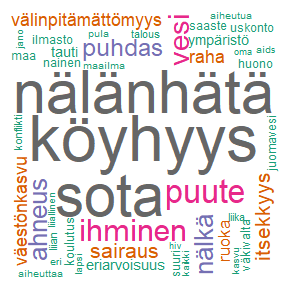

```r
fst_wordcloud(df)
```

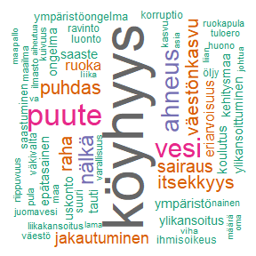

```r
# We can only get weights from svydesign if they are NOT already in our formatted data. Hence we remove them for this demonstration!
df2$weight <- NULL
fst_wordcloud(df2,
              pos_filter = c("NOUN", "VERB", "ADJ", "ADV"),
              max=100,
              use_svydesign_weights = TRUE,
              id = 'fsd_id',
              svydesign = svy_dev)
```

### N-gram plots

Then, we have functions to identify and plot the most frequent words or n-grams (sets of n words in order).

```r
# FUNCTION DEFINITIONS
fst_freq <- function(data,
                     number = 10,
                     norm = NULL,
                     pos_filter = NULL,
                     strict = TRUE,
                     name = NULL,
                     use_svydesign_weights = FALSE,
                     id = "",
                     svydesign = NULL,
                     use_column_weights = FALSE)

fst_ngrams <- function(data,
                       number = 10,
                       ngrams = 1,
                       norm = NULL,
                       pos_filter = NULL,
                       strict = TRUE,
                       name = NULL,
                       use_svydesign_weights = FALSE,
                       id = "",
                       svydesign = NULL,
                       use_column_weights = FALSE)
```

**Summary of components**

- `data` is the formatted data.
- `number` is the number of top words/ngrams to display
- `ngrams` is the type of n-grams, default is `1`.
- `norm` is an optional method for normalising the data. Valid settings are “number_words” (the number of words in the responses), “number_resp” (the number of responses), or NULL (raw count returned, **default**, also used when weights are applied).
- `pos_filter` is an optional list of POS tags for inclusion. The default is NULL.
- `strict` is whether to strictly cut-off at `number` (ties are alphabetically ordered). The default value is TRUE.
- The `name` is an optional “name” for the plot to add to title, default is NULL.

Then, we again have options for weighting the words in the plot. Again, these all default to **not** include weights.

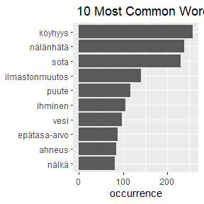

```r
fst_freq(df)
```

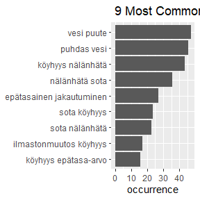

```r
fst_ngrams(df,
           number = 9,
           ngrams = 2,
           strict = FALSE,
           use_column_weights = TRUE)
```

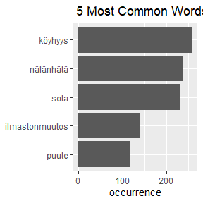

```r
fst_freq(df,
         number = 5,
         strict = FALSE,)
```

(`fst_freq_table()` and `fst_ngrams_table()` can be used to instead create tables of the top words.)

```r
fst_freq_table(df, number = 15, strict = FALSE)
```

```
##                 words occurrence
## 1             köyhyys        258
## 2           nälänhätä        239
## 3                sota        231
## 4      ilmastonmuutos        141
## 5               puute        117
## 6             ihminen        105
## 7                vesi         98
## 8        epätasa-arvo         87
## 9              ahneus         84
## 10              nälkä         81
## 11             puhdas         75
## 12            sairaus         59
## 13          itsekkyys         58
## 14       väestönkasvu         48
## 15 välinpitämättömyys         47
```

# 3. Concept Network

The finnsurveytext package currently contains our first iteration of a function which plots a concept network. These plots visualise keywords which are identified through the TextRank algorithm and maps co-occurrences between these terms. Vertices represent words with vertex size indicating word importance and co-occurrence between words is shown through edges with edge thickness indicating number of co-occurrences. Word importance is determined recursively (through the unsupervised TextRank algorithm, a graph-based ranking model for text processing) where words get more weight based on how many words co-occur and the weight of these co-occurring words. The concept network functions take search terms input by the user and the algorithm then suggests other words that are related to these input terms by co-occurrence. The input terms can be identified through functions in the package (such as `fst_cn_search()` or `fst_freq_table()`) or through other analysis separately conducted by the user. The concept network function can be used to identify concepts which could be individual words or a group of co-occurring words, or may contain a single ’concept’ whose component words are investigated and identified within a single network plot.

To utilise the TextRank algorithm in finnsurveytext, we use the textrank package. For further information on the package, please see [this documentation](https://CRAN.R-project.org/package=textrank). This package implements the TextRank and PageRank algorithms. (PageRank is the algorithm that Google uses to rank webpages.) You can read about the underlying TextRank algorithm [here](https://web.eecs.umich.edu/~mihalcea/papers/mihalcea.emnlp04.pdf) and about the PageRank algorithm here.

The main concept network function is `fst_concept_network()`. It is defined as follows:

```r
# FUNCTION DEFINITIONS
fst_concept_network <- function(data,
                                concepts,
                                threshold = NULL,
                                norm = NULL,
                                pos_filter = NULL,
                                title = NULL)
```

**Summary of components**

- `data` is the formatted data.
- `concepts` are the concept words around which the network is created.
- `threshold` is a minimum number of occurrences threshold for ‘edge’ between searched term and other word, default is `NULL`. Note, the threshold is applied before normalisation.
- `norm` is an optional method for normalising the data. Valid settings are “number_words” (the number of words in the responses), “number_resp” (the number of responses), or NULL (raw count returned, **default**, also used when weights are applied).
- `pos_filter` is an optional list of POS tags for inclusion. The default is NULL.
- `title` is an optional title for plot, default is `NULL` and a generic title (“TextRank extracted keyword occurrences”) will be used.

For example, we can create the following concept network plots:

[figure not shown]

```r
fst_concept_network(df,
                    concepts = "köyhyys, nälänhätä, sota, ilmastonmuutos, puute",
                    )
```

# 4. Comparison Functions

Recall that when we preprocessed the data, we included two additional columns, gender and region, to allow for comparison between respondents based on these values.

There are counterpart comparison functions for each of the functions we have shown above.

The comparison **summary tables** are defined as follows:

```r
fst_pos_compare <- function(data,
                            field,
                            exclude_nulls = FALSE,
                            rename_nulls = 'null_data')

fst_summarise_compare <- function(data,
                                  field,
                                  exclude_nulls = FALSE,
                                  rename_nulls = 'null_data')

fst_length_compare <- function(data,
                               field,
                               incl_sentences = TRUE,
                               exclude_nulls = FALSE,
                               rename_nulls = 'null_data')
```

**Summary of Components**

- `data` is the formatted data.
- `field` is the column in `data` used for splitting groups
- We can choose whether to include or exclude surveys with no response in our splitting column by setting `exclude_nulls`. The default value is FALSE.
- `rename_nulls` is what to fill empty values with if `exclude_nulls = FALSE`.

Let’s compare our responses based on the region of the respondent:

```r
knitr::kable(fst_pos_compare(df, 'region'))
```

| UPOS | Part_of_Speech_Name | Etelä-Suomi-Count | Etelä-Suomi-Prop | Helsinki-Uusimaa-Count | Helsinki-Uusimaa-Prop | Länsi-Suomi-Count | Länsi-Suomi-Prop | Pohjois- ja Itä-Suomi-Count | Pohjois- ja Itä-Suomi-Prop | null_data-Count | null_data-Prop |
| --- | --- | --- | --- | --- | --- | --- | --- | --- | --- | --- | --- |
| ADJ | adjective | 79 | 0.101 | 118 | 0.098 | 105 | 0.083 | 84 | 0.094 | 3 | 0.188 |
| ADP | adposition | 4 | 0.005 | 11 | 0.009 | 6 | 0.005 | 3 | 0.003 | 0 | 0.000 |
| ADV | adverb | 8 | 0.010 | 20 | 0.017 | 22 | 0.017 | 13 | 0.014 | 1 | 0.062 |
| AUX | auxiliary | 1 | 0.001 | 1 | 0.001 | 1 | 0.001 | 0 | 0.000 | 0 | 0.000 |
| CCONJ | coordinating conjunction | 1 | 0.001 | 0 | 0.000 | 1 | 0.001 | 1 | 0.001 | 0 | 0.000 |
| DET | determiner | 6 | 0.008 | 10 | 0.008 | 7 | 0.006 | 5 | 0.006 | 0 | 0.000 |
| INTJ | interjection | 0 | 0.000 | 2 | 0.002 | 0 | 0.000 | 0 | 0.000 | 0 | 0.000 |
| NOUN | noun | 610 | 0.776 | 926 | 0.772 | 1020 | 0.804 | 718 | 0.800 | 12 | 0.750 |
| NUM | numeral | 1 | 0.001 | 1 | 0.001 | 3 | 0.002 | 0 | 0.000 | 0 | 0.000 |
| PART | particle | 2 | 0.003 | 15 | 0.013 | 9 | 0.007 | 3 | 0.003 | 0 | 0.000 |
| PRON | pronoun | 1 | 0.001 | 4 | 0.003 | 3 | 0.002 | 4 | 0.004 | 0 | 0.000 |
| PROPN | proper noun | 3 | 0.004 | 12 | 0.010 | 14 | 0.011 | 2 | 0.002 | 0 | 0.000 |
| PUNCT | punctuation | 0 | 0.000 | 0 | 0.000 | 0 | 0.000 | 0 | 0.000 | 0 | 0.000 |
| SCONJ | subordinating conjunction | 0 | 0.000 | 0 | 0.000 | 0 | 0.000 | 0 | 0.000 | 0 | 0.000 |
| SYM | symbol | 0 | 0.000 | 1 | 0.001 | 0 | 0.000 | 0 | 0.000 | 0 | 0.000 |
| VERB | verb | 69 | 0.088 | 72 | 0.060 | 75 | 0.059 | 62 | 0.069 | 0 | 0.000 |
| X | other | 1 | 0.001 | 6 | 0.005 | 3 | 0.002 | 2 | 0.002 | 0 | 0.000 |

```r
knitr::kable(fst_summarise_compare(df, 'region'))
```

| Description | Respondents | No Response | Proportion | Total Words | Unique Words | Unique Lemmas |
| --- | --- | --- | --- | --- | --- | --- |
| Etelä-Suomi | 176 | 0 | 1.00 | 786 | 360 | 336 |
| Helsinki-Uusimaa | 259 | 10 | 0.96 | 1209 | 493 | 443 |
| Länsi-Suomi | 276 | 8 | 0.97 | 1277 | 478 | 425 |
| Pohjois- ja Itä-Suomi | 206 | 7 | 0.97 | 904 | 338 | 309 |
| null_data | 3 | 0 | 1.00 | 16 | 16 | 16 |

```r
knitr::kable(fst_length_compare(df, 'region'))
```

| Description | Respondents | Mean | Minimum | Q1 | Median | Q3 | Maximum |
| --- | --- | --- | --- | --- | --- | --- | --- |
| Etelä-Suomi- Words | 176 | 5.483 | 2 | 4.0 | 5 | 6 | 23 |
| Etelä-Suomi- Sentences | 176 | 1.017 | 1 | 1.0 | 1 | 1 | 3 |
| Helsinki-Uusimaa- Words | 259 | 5.579 | 1 | 4.0 | 5 | 6 | 25 |
| Helsinki-Uusimaa- Sentences | 259 | 1.023 | 1 | 1.0 | 1 | 1 | 3 |
| Länsi-Suomi- Words | 276 | 5.620 | 1 | 4.0 | 5 | 6 | 32 |
| Länsi-Suomi- Sentences | 276 | 1.007 | 1 | 1.0 | 1 | 1 | 2 |
| Pohjois- ja Itä-Suomi- Words | 206 | 5.311 | 1 | 4.0 | 5 | 6 | 20 |
| Pohjois- ja Itä-Suomi- Sentences | 206 | 1.015 | 1 | 1.0 | 1 | 1 | 2 |
| null_data- Words | 3 | 6.333 | 5 | 5.5 | 6 | 7 | 8 |
| null_data- Sentences | 3 | 1.000 | 1 | 1.0 | 1 | 1 | 1 |

The **ngrams** comparison functions are defined similarly (with some additional new values):

```r
# FUNCTION DEFINITIONS
fst_freq_compare <- function(data,
                             field,
                             number = 10,
                             norm = NULL,
                             pos_filter = NULL,
                             strict = TRUE,
                             use_svydesign_weights = FALSE,
                             id = "",
                             svydesign = NULL,
                             use_column_weights = FALSE,
                             exclude_nulls = FALSE,
                             rename_nulls = 'null_data',
                             unique_colour = "indianred",
                             title_size = 20,
                             subtitle_size = 15)


fst_ngrams_compare <- function(data,
                              field,
                              number = 10,
                              ngrams = 1,
                              norm = NULL,
                              pos_filter = NULL,
                              strict = TRUE,
                              use_svydesign_weights = FALSE,
                              id = "",
                              svydesign = NULL,
                              use_column_weights = FALSE,
                              exclude_nulls = FALSE,
                              rename_nulls = 'null_data',
                              unique_colour = "indianred",
                              title_size = 20,
                              subtitle_size = 15)
```

The **new components** are:

- `unique_colour` is chosen to differentiate values which are unique to one group of respondents, the default is “indianred”
- `title_size` and `subtitle_size` set these, you may need to change them from the default values if any of your group names are long or if there are many groups.

For the ngrams, let’s compare respondents by gender.

[figure not shown]

```r
fst_freq_compare(df,
                 'gender',
                 use_column_weights = TRUE,
                 exclude_nulls = TRUE)
```

[figure not shown]

```r
fst_ngrams_compare(df,
                   'gender',
                   ngrams = 2,
                   use_column_weights = TRUE,
                   exclude_nulls = TRUE)
```

The **comparison cloud** extends the wordcloud concept.

A comparison cloud compares the relative frequency with which a term is used in two or more documents. This cloud shows words that occur more regularly in responses from a specific type of respondent. For more information about comparison clouds, you can read [this documentation](https://CRAN.R-project.org/package=wordcloud).

The comparison cloud is defined as follows, with settings as defined for the previous functions:

```r
# FUNCTION DEFINITION
fst_comparison_cloud <- function(data,
                                 field,
                                 pos_filter = NULL,
                                 norm = NULL,
                                 max = 100,
                                 use_svydesign_weights = FALSE,
                                 id = "",
                                 svydesign = NULL,
                                 use_column_weights = FALSE,
                                 exclude_nulls = FALSE,
                                 rename_nulls = "null_data")
```

Thus, we can create comparison clouds:

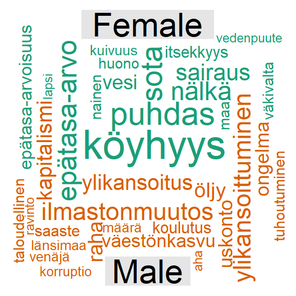

```r
fst_comparison_cloud(df, 'gender', max = 40, use_column_weights = TRUE, exclude_nulls = TRUE)
```

Finally we have the comparison **concept network** which has the following components which should be familiar from previous functions:

```r
# FUNCTION DEFINITION
fst_concept_network_compare <- function(data,
                                        concepts,
                                        field,
                                        norm = NULL,
                                        threshold = NULL,
                                        pos_filter = NULL,
                                        exclude_nulls = FALSE,
                                        rename_nulls = 'null_data',
                                        title_size = 20,
                                        subtitle_size = 15)
```

We run the comparison concept network as follows:

[figure not shown]

```r
fst_concept_network_compare(df,
                            concepts = "köyhyys, nälänhätä, sota, ilmastonmuutos, puute",
                            'gender',
                            exclude_nulls = TRUE
                            )
```

For more information on the `finnsurveytext` functions, see the [package website](https://dariah-fi-survey-concept-network.github.io/finnsurveytext/) and documentation available from the [CRAN](https://CRAN.R-project.org/package=finnsurveytext).

# Data

The package comes with sample data from two Finnish surveys obtained from the Finnish Social Science Data Archive an a survey in English available from GESIS:

#### 1. Child Barometer Data

- Source: FSD3134 Lapsibarometri 2016
- Question: q7 ‘Kertoisitko, mitä sinun mielestäsi kiusaaminen on? (Avokysymys)’
- Licence: (A) openly available for all users without registration (CC BY 4.0).
- Link to Data: https://urn.fi/urn:nbn:fi:fsd:T-FSD3134

#### 2. Development Cooperation Data

- Source: FSD2821 Nuorten ajatuksia kehitysyhteistyöstä 2012
- Questions: q11_1 ‘Jatka lausetta: Kehitysmaa on maa, jossa… (Avokysymys)’, q11_2 ‘Jatka lausetta: Kehitysyhteistyö on toimintaa, jossa… (Avokysymys)’, q11_3 ‘Jatka lausetta: Maailman kolme suurinta ongelmaa ovat… (Avokysymys)’
- Licence: (A) openly available for all users without registration (CC BY 4.0).
- Link to Data: https://urn.fi/urn:nbn:fi:fsd:T-FSD2821

#### 3. Patient Joe (open-ended question)

- Source: GESIS – Leibniz Institute for the Social Sciences
- Open-ended question: ‘Joe’s doctor told him that he would need to return in two weeks to find out whether or not his condition had improved. But when Joe asked the receptionist for an appointment, he was told that it would be over a month before the next available appointment. What should Joe do?’
- Licence: CC BY 4.0: Attribution
- Link to Data: https://doi.org/10.7802/2474